# HUC Analysis

## Load point sources with HUC-12 and elevations

All of these files were created in get_HUC_elevation.Rmd.

```r
pb_huc_elevation <- st_read("huc_elevation_datasets/pb_HUC_elevation_block.gpkg") %>%
    mutate(POPULATION = na_if(POPULATION, -999)) %>%
  filter(STATUS != "CLOSED") %>%
  mutate(REGION = case_when(
    STATE %in% c("CA", "WA", "OR", "HI", "AK") ~ "PACIFIC",
    STATE %in% c("AZ", "CO", "ID", "NM", "MT", "UT", "NV", "WY") ~ "MOUNTAIN",
    STATE %in% c("IA", "KS", "MN", "MO", "NE","ND", "SD") ~ "WEST NORTH CENTRAL",
    STATE %in% c("IN", "IL", "MI", "OH", "WI") ~ "EAST NORTH CENTRAL",
    STATE %in% c("AR", "LA", "OK", "TX") ~ "WEST SOUTH CENTRAL",
    STATE %in% c("AL", "KY", "MS", "TN") ~ "EAST SOUTH CENTRAL",
    STATE %in% c("NJ", "NY", "PA") ~ "MID ATLANTIC",
    STATE %in% c("MA", "CT", "RI", "VT", "NH", "ME") ~ "NEW ENGLAND",
    STATE %in% c("DE", "DC", "GA", "MD", "NC", "SC", "VA", "WV", "FL") ~ "SOUTH ATLANTIC",
    TRUE ~ "OUTLYING"
    ))
pb_huc_elevation_juv <- pb_huc_elevation %>%
  filter(SECURELVL == "JUVENILE")

pb_huc_elevation_urban <- pb_huc_elevation %>%
  filter(URBAN == "URBAN")

susp_cont_huc_elevation <- st_read("huc_elevation_datasets/susp_cont_HUC_elevation.gpkg") %>%
  mutate(Source = case_when(Source == "Formerly Used Defense Sites" |
                     Source == "Military Installations, Ranges, and Training Areas" ~ "Military Installment",
                   TRUE ~ Source))
pfas_huc_elevation <- st_read("huc_elevation_datasets/pfas_huc_elevation.gpkg") %>%
  mutate(industry = case_when(
    industry == "Military" ~ "Military Installment",
    industry == "Landfill" ~ "Industrial Facilities",
    industry == "Industry" ~ "Industrial Facilities",
    industry == "Fire Department/Training Facility" ~ "Industrial Facilities",
    industry == "Airport" ~ "Major Airports (FAA Part 139)",
    industry == "Unknown" ~ "Other",
    industry == "WWTP" ~ "Wastewater Treatment Plants",
    industry == "Superfund Site" ~ "Industrial Facilities",
    industry == "Dry Cleaner" ~ "Industrial Facilities",
    industry == "Waste" ~ "Waste",
    industry == "Other" ~ "Other"
  ))
```

## How many carceral facilities are missing population data? Are certain types have more missing information than others?

```r
missing_pop_juv <-
  pb_huc_elevation %>%
  st_drop_geometry() %>%
  mutate(MISSING_POPULATION = case_when(is.na(POPULATION) ~ 1,
                             TRUE ~ 0),
         JUVENILE = case_when(SECURELVL == "JUVENILE" ~ "YES",
                              TRUE ~ "NO")) %>%
  group_by(JUVENILE) %>%
  summarize(Total = n(),
            Count_Missing_Pop = sum(MISSING_POPULATION),
            Percent_Missing_Pop = Count_Missing_Pop/n()*100)

missing_pop_type <-
  pb_huc_elevation %>%
  st_drop_geometry() %>%
  mutate(MISSING_POPULATION = case_when(is.na(POPULATION) ~ 1,
                             TRUE ~ 0)) %>%
  group_by(TYPE) %>%
  summarize(Total = n(),
            Count_Missing_Pop = sum(MISSING_POPULATION),
            Percent_Missing_Pop = Count_Missing_Pop/n()*100)
```

## Presumptive and Known Point Source Analysis

### Join Known Point Sources to Carceral Facilities with Shared HUC-12

```r
pb_pfas_joined <-
  pb_huc_elevation %>%
  select(-elev_units) %>%
  rename(ELEVATION_CARCERAL = elevation) %>%
  st_set_geometry(NULL) %>%
  inner_join(pfas_huc_elevation %>%
                 st_set_geometry(NULL),
               by = "HUC") %>%
    filter(ELEVATION_CARCERAL < elevation) %>%
    rename(PFAS_ID_COLUMN = map_id,
           PFAS_NAME = site_name,
           PFAS_INDUSTRY = industry,
           PFAS_SOURCE = suspected_source,
           PFAS_STATE = state,
           PFAS_LEVEL = pfas_level) %>%
    select(FACILITYID, NAME, POPULATION, TYPE, SECURELVL, URBAN, STATE, REGION, PFAS_ID_COLUMN, PFAS_NAME, PFAS_INDUSTRY, PFAS_SOURCE, PFAS_LEVEL, LATITUDE, LONGITUDE)
write.csv(pb_pfas_joined, "final_datasets/pb_pfas_joined.csv")
```

# For each carceral facility determine whether juvenile, colocated to known site, and colocated to presumptive site

Purpose: This data will be used to perform statistical tests.

```r
unique_carc_known <-
  pb_pfas_joined %>%
  distinct(FACILITYID) %>%
  mutate(KNOWN = TRUE) %>%
  select(FACILITYID, KNOWN)

unique_carc_susp <-
  pb_susp_cont_joined %>%
  distinct(FACILITYID) %>%
  mutate(SUSP = TRUE) %>%
  select(FACILITYID, SUSP)

colocated_by_facility <-
  pb_huc_elevation %>%
  st_drop_geometry() %>%
  mutate(JUVENILE = case_when(SECURELVL == "JUVENILE" ~ "JUVENILE",
                              TRUE ~ "NOT_JUVENILE")) %>%
  select(FACILITYID, JUVENILE) %>%
  left_join(unique_carc_susp) %>%
  left_join(unique_carc_known) %>%
  replace_na(list(KNOWN = FALSE, SUSP = FALSE)) %>%
  mutate(DIFF = case_when(SUSP != KNOWN ~ TRUE,
                          TRUE ~ FALSE))
write.csv(colocated_by_facility, "final_datasets/colocated_by_facility.csv")
```

### Calculate Numbers and Percentages of Carceral Facilities in Proximity to Different Thresholds of Point Sources

Purpose:

This code calculates the number, percentage, and populations of carceral facilities in the same HUC-12 and at a lower elevation than each point source. The previous code produced a data frame in which a carceral facility may have been listed multiple times if there was more than one point source in the same HUC-12 and at a higher elevation. This code reduces the file to unique carceral facilities by grouping variables specific to the facility. It then counts the number of observations in the data frame, the percentage of the total carceral facilities in the US this number represents, and the number of inmates potentially impacted. Specifically,

- groups rows representing the same carceral facility,
- filters to groups in which the number of observations (in this case representing proximate point sources) is greater than the threshold,
- selects variables related to carceral facilities and subsets to distinct carceral facilities

After this, the same calculations are performed as those performed above.

```r
point_source_calculation <- function(source, threshold, text) {
  source %>%
  group_by(FACILITYID) %>%
  filter(n() > threshold) %>%
  ungroup() %>%
  select(FACILITYID, POPULATION, TYPE, SECURELVL, URBAN) %>%
  distinct() %>%
  summarize(CARC_FAC_WITH_POINT_SOURCE_IN_HUC = n(),
            PERC_CARC_FAC_WITH_POINT_SOURCE_IN_HUC = n() / nrow(pb_huc_elevation) * 100,
            AT_LEAST_CARC_POP_WITH_POINT_SOURCE_IN_HUC = sum(POPULATION, na.rm = TRUE),
            JUV_CARC_FAC_WITH_POINT_SOURCE_IN_HUC = sum(SECURELVL == "JUVENILE"),
            PERC_JUV_CARC_FAC_WITH_POINT_SOURCE_IN_HUC = sum(SECURELVL == "JUVENILE") / nrow(pb_huc_elevation_juv) * 100,
            AT_LEAST_JUV_CARC_POP_WITH_POINT_SOURCE_IN_HUC = sum(POPULATION[SECURELVL == "JUVENILE"], na.rm = TRUE),
            NON_JUV_CARC_FAC_WITH_POINT_SOURCE_IN_HUC = sum(SECURELVL != "JUVENILE"),
            PERC_NON_JUV_CARC_FAC_WITH_POINT_SOURCE_IN_HUC = sum(SECURELVL != "JUVENILE") / (nrow(pb_huc_elevation) - nrow(pb_huc_elevation_juv)) * 100,
            AT_LEAST_NON_JUV_CARC_POP_WITH_POINT_SOURCE_IN_HUC = sum(POPULATION[SECURELVL != "JUVENILE"], na.rm = TRUE),
            URBAN_CARC_FAC_WITH_POINT_SOURCE_IN_HUC = sum(URBAN == "URBAN"),
            PERC_URBAN_CARC_FAC_WITH_POINT_SOURCE_IN_HUC = sum(URBAN == "URBAN") / nrow(pb_huc_elevation_urban) * 100,
            AT_LEAST_URBAN_CARC_POP_WITH_POINT_SOURCE_IN_HUC = sum(POPULATION[URBAN == "URBAN"], na.rm = TRUE),
            NON_URBAN_CARC_FAC_WITH_POINT_SOURCE_IN_HUC = sum(URBAN != "URBAN"),
            PERC_NON_URBAN_CARC_FAC_WITH_POINT_SOURCE_IN_HUC = sum(URBAN != "URBAN") / (nrow(pb_huc_elevation) - nrow(pb_huc_elevation_urban)) * 100,
            AT_LEAST_NON_URBAN_CARC_POP_WITH_POINT_SOURCE_IN_HUC = sum(POPULATION[URBAN != "URBAN"], na.rm = TRUE)
            ) %>%
  mutate(SUSP_CONT_SOURCE = paste("More than", threshold, text, "point sources" )) %>%
  relocate(SUSP_CONT_SOURCE, .before = CARC_FAC_WITH_POINT_SOURCE_IN_HUC)
}

at_least_one_susp_source <- point_source_calculation(pb_susp_cont_joined, 0, "presumptive")
more_than_one_susp_source <- point_source_calculation(pb_susp_cont_joined, 1, "presumptive")
more_than_five_susp_source <- point_source_calculation(pb_susp_cont_joined, 5, "presumptive")
at_least_one_known_source <- point_source_calculation(pb_pfas_joined, 0, "known")
more_than_one_known_source <- point_source_calculation(pb_pfas_joined, 1, "known")
more_than_five_known_source <- point_source_calculation(pb_pfas_joined, 5, "known")

totals_table <-
  rbind(at_least_one_susp_source,
        more_than_one_susp_source,
        more_than_five_susp_source,
        at_least_one_known_source,
        more_than_one_known_source,
        more_than_five_known_source)

write.csv(totals_table, "final_datasets/totals_table.csv")

rm(at_least_one_susp_source,
   more_than_one_susp_source,
   more_than_five_susp_source,
   at_least_one_known_source,
   more_than_one_known_source,
   more_than_five_known_source
)
```

### Perform Presumptive Point Source Calculations by Type

This takes the data frame created above in which each row represents a carceral facility/proximate PFAS point source pair. First it determines the distinct not closed carceral facilities that are proximate to at least one point source. The number of rows in this data frame is used as the denominator when calculating percentages in the first columns of this table. The number of rows in this data frame is used as the denominator when calculating percentages in the final columns of this table. It then calculates the number, percentage, and populations of not closed carceral facilities proximate to at least one point source.

```r
facility_type_totals <-
  pb_huc_elevation %>%
  st_drop_geometry() %>%
  group_by(TYPE) %>%
  summarize(TYPE_COUNT = n(),
            JUV_TYPE_COUNT = sum(SECURELVL == "JUVENILE", na.rm = TRUE),
            NON_JUV_TYPE_COUNT = sum(SECURELVL != "JUVENILE", na.rm = TRUE),
            POP_COUNT = sum(POPULATION, na.rm = TRUE))

by_type_table <- function(source){

  pbs_at_least_one <-
    source %>%
    select(FACILITYID, POPULATION, TYPE, SECURELVL) %>%
    distinct()

  pbs_at_least_one_juv <-
    pbs_at_least_one %>%
    filter(SECURELVL == "JUVENILE")

  by_pb_type <-
    pbs_at_least_one %>%
    left_join(facility_type_totals, by = "TYPE") %>%
    group_by(TYPE) %>%
    summarize(CARC_FAC_WITH_POINT_SOURCE_IN_HUC = n(),
              PERC_CARC_FAC_DENOM_TOTAL_IN_HUC =
                n() / nrow(pbs_at_least_one) * 100,
              PERC_CARC_FAC_DENOM_TOTAL_OF_TYPE =
                n() / TYPE_COUNT * 100,
              AT_LEAST_CARC_POP_WITH_POINT_SOURCE_IN_HUC =
                sum(POPULATION, na.rm = TRUE),
              JUV_CARC_FAC_WITH_POINT_SOURCE_IN_HUC =
                sum(SECURELVL == "JUVENILE", na.rm = TRUE),
              PERC_JUV_CARC_FAC_DENOM_TOTAL_IN_HUC =
                sum(SECURELVL == "JUVENILE", na.rm = TRUE) /
                nrow(pbs_at_least_one_juv) * 100,
              PERC_JUV_CARC_FAC_DENOM_TOTAL_OF_TYPE =
                sum(SECURELVL == "JUVENILE", na.rm = TRUE) /
                JUV_TYPE_COUNT * 100,
              AT_LEAST_JUV_CARC_POP_WITH_POINT_SOURCE_IN_HUC =
                sum(POPULATION[SECURELVL == "JUVENILE"], na.rm = TRUE),
              NON_JUV_CARC_FAC_WITH_POINT_SOURCE_IN_HUC =
                sum(SECURELVL != "JUVENILE", na.rm = TRUE),
              PERC_NON_JUV_CARC_FAC_DENOM_TOTAL_IN_HUC =
                sum(SECURELVL != "JUVENILE", na.rm = TRUE) /
                (nrow(pbs_at_least_one) -
                   nrow(pbs_at_least_one_juv)) * 100,
              PERC_NON_JUV_CARC_FAC_DENOM_TOTAL_OF_TYPE =
                sum(SECURELVL != "JUVENILE", na.rm = TRUE) /
                NON_JUV_TYPE_COUNT * 100,
              AT_LEAST_NON_JUV_CARC_POP_WITH_POINT_SOURCE_IN_HUC =
                sum(POPULATION[SECURELVL != "JUVENILE"], na.rm = TRUE)) %>%
    distinct()


}

susp_by_pb_type <- by_type_table(pb_susp_cont_joined)
known_by_pb_type <- by_type_table(pb_pfas_joined)
write.csv(susp_by_pb_type, "final_datasets/susp_by_pb_type.csv")
write.csv(known_by_pb_type, "final_datasets/known_by_pb_type.csv")
```

### Perform Presumptive Point Source Calculations by Region

This takes the data frame created above in which each row represents a carceral facility/proximate PFAS point source pair. First it determines the distinct not closed carceral facilities that are proximate to at least one point source. The number of rows in this data frame is used as the denominator when calculating percentages in the first columns of this table. The number of rows in this data frame is used as the denominator when calculating percentages in the final columns of this table. It then calculates the number, percentage, and populations of not closed carceral facilities proximate to at least one point source by region.

```r
facility_region_totals <-
  pb_huc_elevation %>%
  st_drop_geometry() %>%
  group_by(REGION) %>%
  summarize(REGION_COUNT = n(),
            JUV_REGION_COUNT = sum(SECURELVL == "JUVENILE", na.rm = TRUE),
            NON_JUV_REGION_COUNT = sum(SECURELVL != "JUVENILE", na.rm = TRUE),
            POP_COUNT = sum(POPULATION, na.rm = TRUE))

by_region_table <- function(source){

  pbs_at_least_one <-
    source %>%
    select(FACILITYID, POPULATION, REGION, SECURELVL) %>%
    distinct()

  pbs_at_least_one_juv <-
    pbs_at_least_one %>%
    filter(SECURELVL == "JUVENILE")

  by_pb_region <-
    pbs_at_least_one %>%
    left_join(facility_region_totals, by = "REGION") %>%
    group_by(REGION) %>%
    summarize(CARC_FAC_WITH_POINT_SOURCE_IN_HUC = n(),
              PERC_CARC_FAC_DENOM_TOTAL_IN_HUC =
                n() / nrow(pbs_at_least_one) * 100,
              PERC_CARC_FAC_DENOM_TOTAL_OF_REGION =
                n() / REGION_COUNT * 100,
              AT_LEAST_CARC_POP_WITH_POINT_SOURCE_IN_HUC =
                sum(POPULATION, na.rm = TRUE),
              JUV_CARC_FAC_WITH_POINT_SOURCE_IN_HUC =
                sum(SECURELVL == "JUVENILE", na.rm = TRUE),
              PERC_JUV_CARC_FAC_DENOM_TOTAL_IN_HUC =
                sum(SECURELVL == "JUVENILE", na.rm = TRUE) /
                nrow(pbs_at_least_one_juv) * 100,
              PERC_JUV_CARC_FAC_DENOM_TOTAL_OF_REGION =
                sum(SECURELVL == "JUVENILE", na.rm = TRUE) /
                JUV_REGION_COUNT * 100,
              AT_LEAST_JUV_CARC_POP_WITH_POINT_SOURCE_IN_HUC =
                sum(POPULATION[SECURELVL == "JUVENILE"], na.rm = TRUE),
              NON_JUV_CARC_FAC_WITH_POINT_SOURCE_IN_HUC =
                sum(SECURELVL != "JUVENILE", na.rm = TRUE),
              PERC_NON_JUV_CARC_FAC_DENOM_TOTAL_IN_HUC =
                sum(SECURELVL != "JUVENILE", na.rm = TRUE) /
                (nrow(pbs_at_least_one) -
                   nrow(pbs_at_least_one_juv)) * 100,
              PERC_NON_JUV_CARC_FAC_DENOM_TOTAL_OF_REGION =
                sum(SECURELVL != "JUVENILE", na.rm = TRUE) /
                NON_JUV_REGION_COUNT * 100,
              AT_LEAST_NON_JUV_CARC_POP_WITH_POINT_SOURCE_IN_HUC =
                sum(POPULATION[SECURELVL != "JUVENILE"], na.rm = TRUE)) %>%
    distinct()


}

susp_by_pb_region <- by_region_table(pb_susp_cont_joined)
known_by_pb_region <- by_region_table(pb_pfas_joined)
write.csv(susp_by_pb_region, "final_datasets/susp_by_pb_region.csv")
write.csv(known_by_pb_region, "final_datasets/known_by_pb_region.csv")
```

## Plots

### Counts of Carceral Facilities in Proximity to Point Source

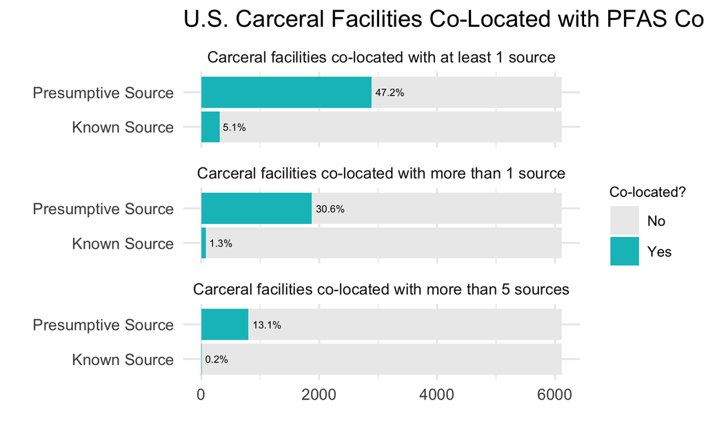

```r
susp_colocated_facilities <-
  pb_susp_cont_joined %>%
  group_by(FACILITYID) %>%
  summarize(SUSP_COLOCATED = "Yes",
            NUM_SUSP_COLOCATED = n()) %>%
  ungroup() %>%
  mutate(SUSP_MORE_1_COLOCATED = case_when(NUM_SUSP_COLOCATED > 1 ~ "Yes",
                                            TRUE ~ "No"),
         SUSP_MORE_5_COLOCATED = case_when(NUM_SUSP_COLOCATED > 5 ~ "Yes",
                                            TRUE ~ "No")) %>%
  select(FACILITYID, SUSP_COLOCATED, SUSP_MORE_1_COLOCATED, SUSP_MORE_5_COLOCATED)

known_colocated_facilities <-
  pb_pfas_joined %>%
  group_by(FACILITYID) %>%
  summarize(KNOWN_COLOCATED = "Yes",
            NUM_KNOWN_COLOCATED = n()) %>%
  ungroup() %>%
  mutate(KNOWN_MORE_1_COLOCATED = case_when(NUM_KNOWN_COLOCATED > 1 ~ "Yes",
                                            TRUE ~ "No"),
         KNOWN_MORE_5_COLOCATED = case_when(NUM_KNOWN_COLOCATED > 5 ~ "Yes",
                                            TRUE ~ "No")) %>%
  select(FACILITYID, KNOWN_COLOCATED, KNOWN_MORE_1_COLOCATED, KNOWN_MORE_5_COLOCATED)


summary_colocation_counts <- pb_huc_elevation %>%
  st_drop_geometry() %>%
  left_join(susp_colocated_facilities, by = "FACILITYID") %>%
  left_join(known_colocated_facilities, by = "FACILITYID") %>%
  pivot_longer(SUSP_COLOCATED:KNOWN_MORE_5_COLOCATED,
              names_to = "MEASURE",
              values_to = "VALUE") %>%
  mutate(VALUE = case_when(is.na(VALUE) ~ "No", TRUE ~ VALUE)) %>%
  separate(MEASURE, into = c("DATA_SOURCE", "COLOCATED"), sep = "_", extra = "merge") %>%
  mutate(DATA_SOURCE = case_when(DATA_SOURCE == "SUSP" ~ "Presumptive Source",
                                 DATA_SOURCE == "KNOWN" ~ "Known Source")) %>%
    mutate(COLOCATED = case_when(COLOCATED == "COLOCATED" ~ "Carceral facilities co-located with at least 1 source",
                                 COLOCATED == "MORE_1_COLOCATED" ~ "Carceral facilities co-located with more than 1 source",
                                 COLOCATED == "MORE_5_COLOCATED" ~ "Carceral facilities co-located with more than 5 sources"))

summary_colocation_counts %>%
ggplot(aes(x = DATA_SOURCE, fill = VALUE)) +
  geom_bar() +
  facet_wrap(vars(COLOCATED), nrow = 3) +
  coord_flip() +
  theme_minimal()  +
  labs(title = "U.S. Carceral Facilities Co-Located with PFAS Contamination Sources",
       x = "",
       y = "",
       fill = "Co-located?") +
  theme(legend.title = element_text(size = 8),
        legend.text = element_text(size = 8)) +
  scale_fill_manual(values=c("#ececec", "#00bfc4")) +
  geom_text(data = summary_colocation_counts %>% filter(VALUE == "Yes"),
            aes(label = paste0(round(..count../nrow(pb_huc_elevation) * 100,
                                     digits = 1), "%")),
            stat = "count",
            colour = "black",
            size = 2,
            hjust = -0.15)


ggsave("final_datasets/summary_plot.png",
  plot = last_plot(),
  scale = 1,
  width = 2600,
  height = 1600,
  units = "px",
  dpi = 300,
)
```

```r
rm(susp_colocated_facilities, known_colocated_facilities)
```

### Counts of Carceral Facilities in Proximity to Point Source, Elaborated

```r
library(ggpubr)
susp_colocated_facilities_source <-
  pb_susp_cont_joined %>%
  group_by(FACILITYID) %>%
  summarize(SUSP_COLOCATED = "Yes",
            SUSP_POINT_SOURCE = paste0(unique(SUSP_CONT_SOURCE), collapse = ";")) %>%
  ungroup() %>%
  mutate(SUSP_POINT_SOURCE = case_when(str_detect(SUSP_POINT_SOURCE, ";") ~ "Multiple",
                            TRUE ~ SUSP_POINT_SOURCE)) %>%
  select(FACILITYID, SUSP_COLOCATED, SUSP_POINT_SOURCE)

known_colocated_facilities_source <-
  pb_pfas_joined  %>%
  group_by(FACILITYID) %>%
  summarize(KNOWN_COLOCATED = "Yes",
            KNOWN_POINT_SOURCE = paste0(unique(PFAS_INDUSTRY, collapse = ";"))) %>%
  ungroup() %>%
  mutate(KNOWN_POINT_SOURCE = case_when(str_detect(KNOWN_POINT_SOURCE, ";") ~ "Multiple",
                            TRUE ~ KNOWN_POINT_SOURCE)) %>%
  select(FACILITYID, KNOWN_COLOCATED, KNOWN_POINT_SOURCE)
summary_colocation_counts_source <- pb_huc_elevation %>%
  st_drop_geometry() %>%
  mutate(JUVENILE = case_when(SECURELVL == "JUVENILE" ~ "Juvenile",
                              TRUE ~ "Adult")) %>%
  left_join(susp_colocated_facilities_source, by = c("FACILITYID")) %>%
  left_join(known_colocated_facilities_source, by = c("FACILITYID")) %>%
  pivot_longer(SUSP_COLOCATED:KNOWN_POINT_SOURCE,
              names_to = "MEASURE",
              values_to = "VALUE") %>%
  mutate(VALUE = case_when(is.na(VALUE) ~ "No", TRUE ~ VALUE)) %>%
  separate(MEASURE, into = c("DATA_SOURCE", "MEASURE"), sep = "_", extra = "merge") %>%
  mutate(DATA_SOURCE = case_when(DATA_SOURCE == "SUSP" ~ "Presumptive Source",
                                 DATA_SOURCE == "KNOWN" ~ "Known Source"))

a <- summary_colocation_counts_source %>%
  filter(MEASURE == "COLOCATED") %>%
ggplot(aes(x = DATA_SOURCE, fill = VALUE)) +
  geom_bar() +
  coord_flip() +
  theme_minimal()  +
  labs(title = "U.S. Carceral Facilities Co-Located with PFAS Contamination Sources",
       x = "",
       y = "",
       fill = "Co-located?") +
  theme(legend.title = element_text(size = 8),
        legend.text = element_text(size = 8)) +
  scale_fill_manual(values=c("#ececec", "#00bfc4")) +
  geom_text(data = summary_colocation_counts_source %>% filter(VALUE == "Yes"),
            aes(label = paste0(round(..count../nrow(pb_huc_elevation) * 100,
                                     digits = 1), "%")),
            stat = "count",
            colour = "black",
            size = 2,
            hjust = -0.15)

b <- summary_colocation_counts_source %>%
  filter(MEASURE == "POINT_SOURCE" & VALUE != "No") %>%
  ggplot(aes(x = DATA_SOURCE, fill = VALUE)) +
  geom_bar(position = "dodge") +
  coord_flip() +
  theme_minimal()  +
  labs(title = "U.S. Carceral Facilities Co-Located with PFAS Contamination Sources, by Source",
       x = "",
       y = "",
       fill = "Source") +
  theme(legend.title = element_text(size = 8),
        legend.text = element_text(size = 8))

c <- summary_colocation_counts_source %>%
  filter(MEASURE == "COLOCATED" & VALUE != "No") %>%
  ggplot(aes(x = DATA_SOURCE, fill = JUVENILE)) +
  geom_bar(position = "dodge") +
  coord_flip() +
  theme_minimal()  +
  labs(title = "U.S. Carceral Facilities Co-Located with PFAS Contamination Sources, by Juvenile",
       x = "",
       y = "",
       fill = "Juvenile?") +
  theme(legend.title = element_text(size = 8),
        legend.text = element_text(size = 8))

figure <- ggarrange(a, b, c,
                    ncol = 1, nrow = 3)

ggsave("final_datasets/colocated_facilities_summary_plot.png",
  plot = figure,
  scale = 1,
  width = 2600,
  height = 2200,
  units = "px",
  dpi = 300,
)

rm(susp_colocated_facilities_source, known_colocated_facilities_source, a, b, c)
```

### Counts of Carceral Facilities in Proximity to Point Source by Source

#### Presumptive

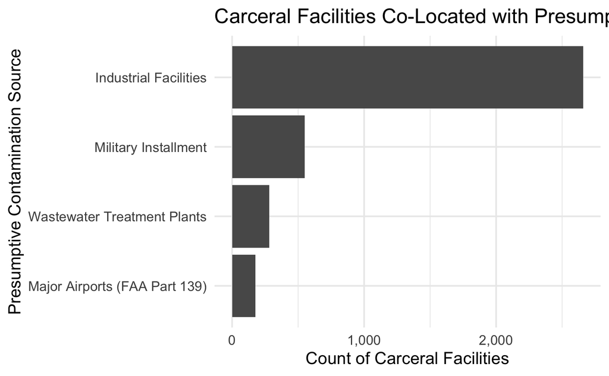

```r
pb_susp_cont_joined %>%
  group_by(SUSP_CONT_SOURCE) %>%
  summarize(COUNT = n_distinct(FACILITYID)) %>%
  ungroup() %>%
  mutate(SUSP_CONT_SOURCE = fct_reorder(SUSP_CONT_SOURCE, COUNT)) %>%
  ggplot(aes(x = SUSP_CONT_SOURCE, y = COUNT)) +
  geom_col() +
  coord_flip() +
  scale_y_continuous(labels = scales::comma) +
  theme_minimal() +
  labs(title = "Carceral Facilities Co-Located with Presumptive PFAS Contamination Sources", x = "Presumptive Contamination Source", y = "Count of Carceral Facilities")

ggsave("final_datasets/susp_fac_by_source.png",
  plot = last_plot(),
  scale = 1,
  width = 2600,
  height = 1200,
  units = "px",
  dpi = 300,
)
```

#### Known

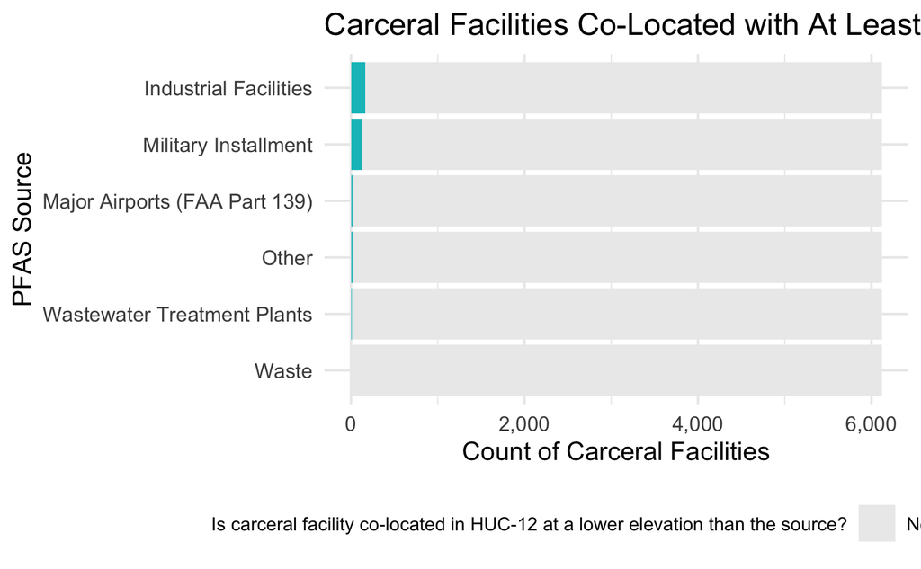

```r
pb_pfas_joined %>%
  group_by(PFAS_INDUSTRY) %>%
  summarize(Yes = n_distinct(FACILITYID),
            No = nrow(pb_huc_elevation) - Yes) %>%
  ungroup() %>%
  mutate(PFAS_INDUSTRY = fct_reorder(PFAS_INDUSTRY, Yes)) %>%
  pivot_longer(Yes:No,
    names_to = "COLOCATED",
    values_to = "COUNT") %>%
  ggplot(aes(x = PFAS_INDUSTRY, y = COUNT, fill = COLOCATED)) +
  geom_col() +
  coord_flip() +
  scale_y_continuous(labels = scales::comma) +
  theme_minimal() +
  labs(title = "Carceral Facilities Co-Located with At Least One Known PFAS Contamination Source", x = "PFAS Source", y = "Count of Carceral Facilities", fill = "Is carceral facility co-located in HUC-12 at a lower elevation than the source?") +
  theme(legend.position = "bottom", legend.title = element_text(size = 8), legend.text = element_text(size = 8)) +
  scale_fill_manual(values=c("#ececec", "#00bfc4"))

ggsave("final_datasets/known_fac_by_source.png",
  plot = last_plot(),
  scale = 1,
  width = 3000,
  height = 1200,
  units = "px",
  dpi = 300,
)
```

### Plot Percentages of Carceral Facilities in Proximity to Point Source by Source

#### Presumptive

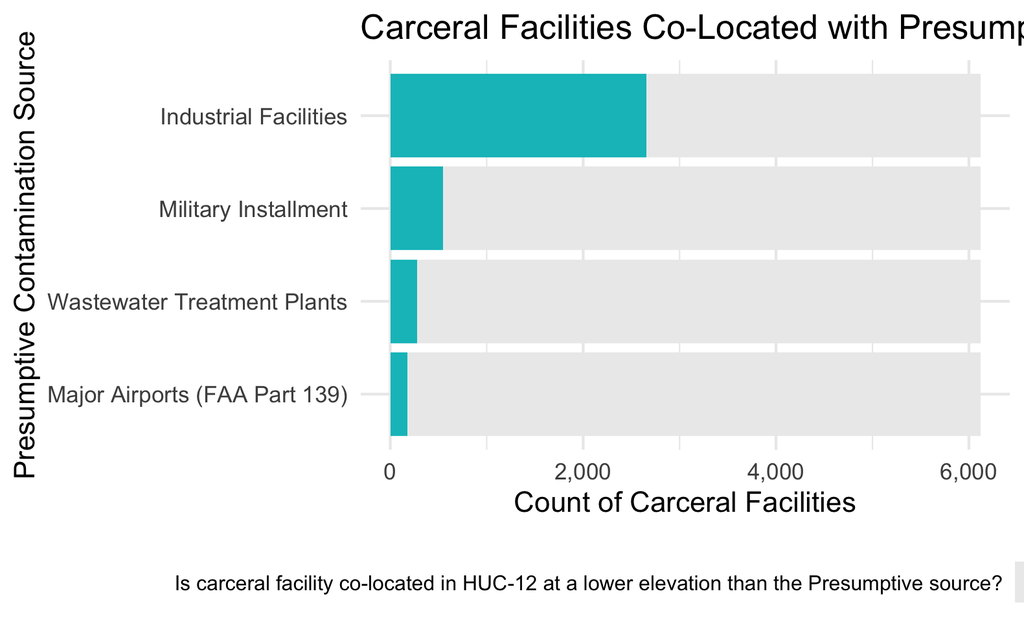

### Plot Populations of Carceral Facilities in Proximity to Point Source by Source

#### Presumptive

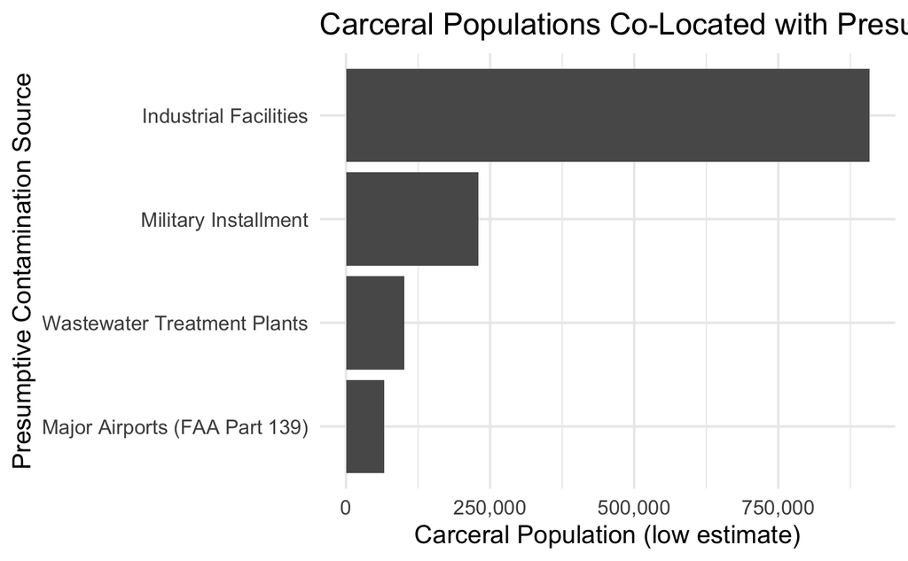

### Plot Population Percentages of Carceral Facilities in Proximity to Point Source by Source

#### Presumptive

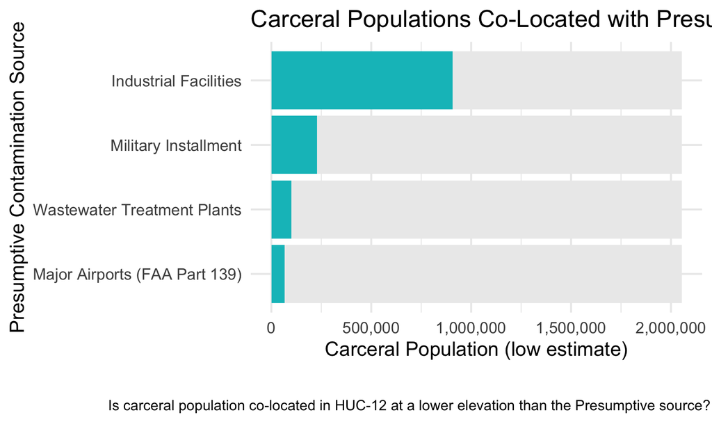

### Plot Counts and Populations of Carceral Facilities in Proximity to Point Source by Source

#### Presumptive

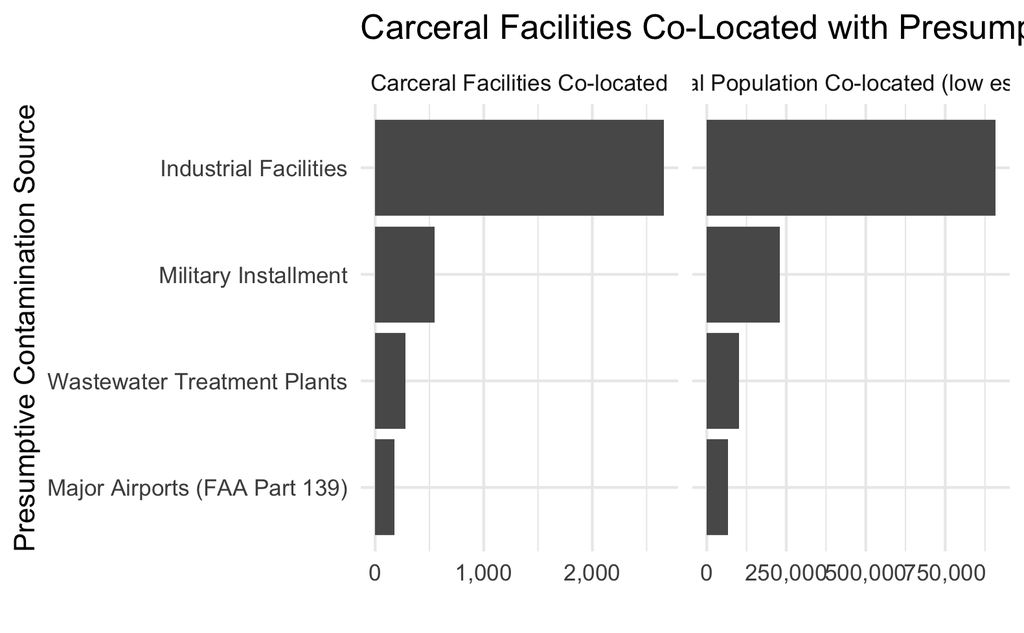

```r
pb_susp_cont_joined %>%
  group_by(SUSP_CONT_SOURCE) %>%
  select(FACILITYID, POPULATION) %>%
  distinct() %>%
  summarize(Yes_Count = n(),
            No_Count = nrow(pb_huc_elevation) - Yes_Count,
            Yes_Population = sum(POPULATION, na.rm = TRUE),
            No_Population = sum(pb_huc_elevation$POPULATION, na.rm = TRUE) - Yes_Population) %>%
  ungroup() %>%
  mutate(SUSP_CONT_SOURCE = fct_reorder(SUSP_CONT_SOURCE, Yes_Count, .fun='max')) %>%
  pivot_longer(Yes_Count:No_Population,
    names_to = "COLOCATED",
    values_to = "VALUE") %>%
  separate(COLOCATED,
           into = c("COLOCATED", "MEASURE"),
           sep = "_") %>%
  filter(COLOCATED == "Yes") %>%
  mutate(MEASURE = case_when(MEASURE == "Population" ~ "Carceral Population Co-located (low estimate)",
                             TRUE ~ "Carceral Facilities Co-located")) %>%
  ggplot(aes(x = SUSP_CONT_SOURCE, y = VALUE)) +
  geom_col() +
  coord_flip() +
  facet_wrap(~MEASURE, scales = "free_x") +
  scale_y_continuous(labels = scales::comma) +
  theme_minimal() +
  labs(title = "Carceral Facilities Co-Located with Presumptive PFAS Contamination Sources",
       x = "Presumptive Contamination Source",
       y = "")
ggsave("final_datasets/susp_fac_pop_by_source.png",
  plot = last_plot(),
  scale = 1,
  width = 3000,
  height = 1200,
  units = "px",
  dpi = 300,
)
```

### Plot Counts and Percentages of Carceral Facilities in Proximity to Point Source by Juvenile

#### Presumptive

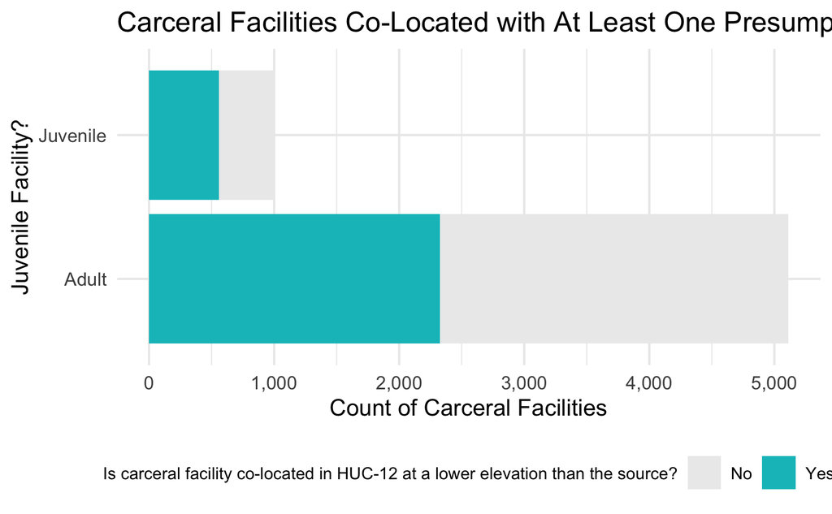

```r
pb_susp_cont_joined %>%
  mutate(JUVENILE = case_when(SECURELVL == "JUVENILE" ~ "Juvenile",
                              TRUE ~ "Adult"),
         DENOM = case_when(SECURELVL == "JUVENILE" ~
                             nrow(pb_huc_elevation %>%
                                    filter(SECURELVL == "JUVENILE")),
                           TRUE ~
                             nrow(pb_huc_elevation %>%
                                    filter(SECURELVL != "JUVENILE")))) %>%
  select(FACILITYID, JUVENILE, DENOM) %>%
  distinct() %>%
  group_by(JUVENILE) %>%
  summarize(Yes = n(),
            No = DENOM - n(),
            Per = Yes/DENOM) %>%
  distinct() %>%
  ungroup() %>%
  pivot_longer(Yes:No,
    names_to = "COLOCATED",
    values_to = "COUNT") %>%
  ggplot(aes(x = JUVENILE, y = COUNT, fill = COLOCATED)) +
  geom_col() +
  coord_flip() +
  scale_y_continuous(labels = scales::comma) +
  theme_minimal() +
  labs(title = "Carceral Facilities Co-Located with At Least One Presumptive PFAS Contamination Source", x = "Juvenile Facility?", y = "Count of Carceral Facilities", fill = "Is carceral facility co-located in HUC-12 at a lower elevation than the source?") +
  theme(legend.position = "bottom", legend.title = element_text(size = 8), legend.text = element_text(size = 8)) +
  scale_fill_manual(values=c("#ececec", "#00bfc4"))
ggsave("final_datasets/susp_fac_by_juv.png",
  plot = last_plot(),
  scale = 1,
  width = 3000,
  height = 1200,
  units = "px",
  dpi = 300,
)
```

#### Known

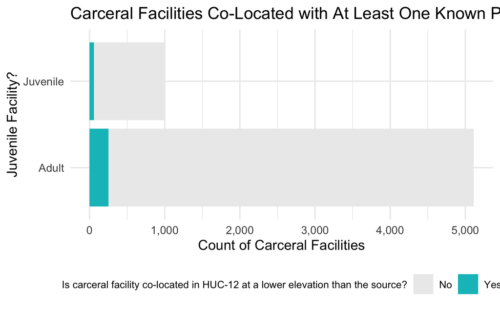

```r
pb_pfas_joined %>%
  mutate(JUVENILE = case_when(SECURELVL == "JUVENILE" ~ "Juvenile",
                              TRUE ~ "Adult"),
         DENOM = case_when(SECURELVL == "JUVENILE" ~
                             nrow(pb_huc_elevation %>%
                                    filter(SECURELVL == "JUVENILE")),
                           TRUE ~
                             nrow(pb_huc_elevation %>%
                                    filter(SECURELVL != "JUVENILE")))) %>%
  select(FACILITYID, JUVENILE, DENOM) %>%
  distinct() %>%
  group_by(JUVENILE) %>%
  summarize(Yes = n(),
            No = DENOM - n(),
            Per = Yes/DENOM) %>%
  distinct() %>%
  ungroup() %>%
  pivot_longer(Yes:No,
    names_to = "COLOCATED",
    values_to = "COUNT") %>%
  ggplot(aes(x = JUVENILE, y = COUNT, fill = COLOCATED)) +
  geom_col() +
  coord_flip() +
  scale_y_continuous(labels = scales::comma) +
  theme_minimal() +
  labs(title = "Carceral Facilities Co-Located with At Least One Known PFAS Contamination Source", x = "Juvenile Facility?", y = "Count of Carceral Facilities", fill = "Is carceral facility co-located in HUC-12 at a lower elevation than the source?") +
  theme(legend.position = "bottom", legend.title = element_text(size = 8), legend.text = element_text(size = 8)) +
  scale_fill_manual(values=c("#ececec", "#00bfc4"))
ggsave("final_datasets/known_fac_by_juv.png",
  plot = last_plot(),
  scale = 1,
  width = 3000,
  height = 1200,
  units = "px",
  dpi = 300,
)
```

#### Presumptive

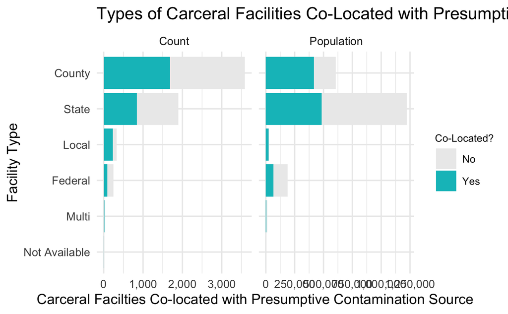

```r
pb_susp_cont_joined %>%
  select(FACILITYID, POPULATION, TYPE) %>%
  left_join(facility_type_totals, by = "TYPE") %>%
  distinct() %>%
  mutate(TYPE = str_to_title(TYPE)) %>%
  group_by(TYPE) %>%
  summarize(Yes_Count = n(),
            No_Count = TYPE_COUNT - n(),
            Yes_Population = sum(POPULATION, na.rm = TRUE),
            No_Population = POP_COUNT - Yes_Population) %>%
  ungroup() %>%
  distinct() %>%
  mutate(TYPE = fct_reorder(TYPE, Yes_Count, .fun='max')) %>%
  pivot_longer(Yes_Count:No_Population,
               names_to = "MEASURE",
               values_to = "VALUE") %>%
  separate(MEASURE, into = c("CO_LOCATED", "MEASURE"), sep = "_") %>%
  ggplot(aes(x = TYPE, y = VALUE, fill = CO_LOCATED)) +
  geom_col() +
  coord_flip() +
  facet_wrap(~MEASURE, scales = "free_x") +
  theme_minimal() +
  scale_y_continuous(labels = scales::comma) +
  labs(title = "Types of Carceral Facilities Co-Located with Presumptive PFAS Contamination Sources",
       x = "Facility Type",
       y = "Carceral Facilties Co-located with Presumptive Contamination Source",
       fill = "Co-Located?") +
  theme(legend.title = element_text(size = 8), legend.text = element_text(size = 8)) +
  scale_fill_manual(values=c("#ececec", "#00bfc4"))
ggsave("final_datasets/susp_fac_pop_by_type.png",
  plot = last_plot(),
  scale = 1,
  width = 3000,
  height = 1200,
  units = "px",
  dpi = 300,
)
```

#### Known

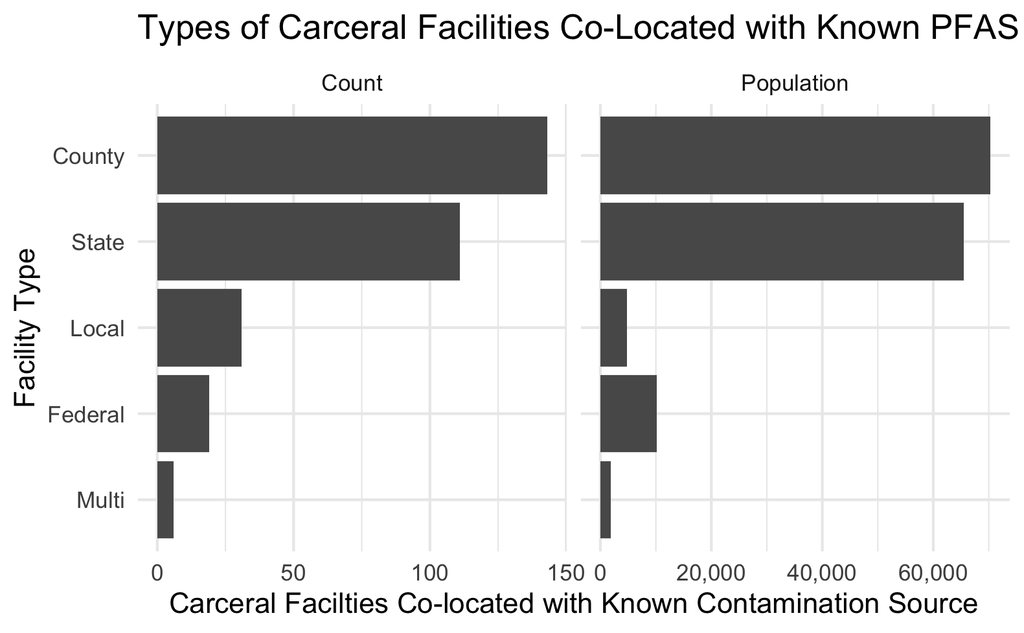

```r
pb_pfas_joined %>%
  select(FACILITYID, POPULATION, TYPE, SECURELVL) %>%
  distinct() %>%
  mutate(TYPE = str_to_title(TYPE)) %>%
  group_by(TYPE) %>%
  summarize(Count = n(),
            Population = sum(POPULATION, na.rm = TRUE)) %>%
  ungroup() %>%
  mutate(TYPE = fct_reorder(TYPE, Count)) %>%
  pivot_longer(Count:Population,
               names_to = "MEASURE",
               values_to = "VALUE") %>%
  ggplot(aes(x = TYPE, y = VALUE)) +
  geom_col() +
  coord_flip() +
  facet_wrap(~MEASURE, scales = "free_x") +
  theme_minimal() +
  scale_y_continuous(labels = scales::comma) +
  labs(title = "Types of Carceral Facilities Co-Located with Known PFAS Contamination Sources",
       x = "Facility Type",
       y = "Carceral Facilties Co-located with Known Contamination Source")

ggsave("final_datasets/known_fac_pop_by_type.png",
  plot = last_plot(),
  scale = 1,
  width = 3000,
  height = 1200,
  units = "px",
  dpi = 300,
)
```